# R Notebook

```r
library(tidyverse)
```

MVP

1. Load the diamonds.csv data set and undertake an initial exploration of the data. You will find a description of the meanings of the variables on the relevant Kaggle page

```r
diamonds_raw <- read_csv("diamonds.csv")
```

```r
view(diamonds_raw)
```

```r
diamonds <- diamonds_raw %>%
  select(-X1)
```

```r
view(diamonds)
```

```r
library(mosaicData)
library(GGally)
library(ggiraphExtra)
```

2. We expect the carat of the diamonds to be strongly correlated with the physical dimensions x, y and z. Use ggpairs() to investigate correlations between these four variables.

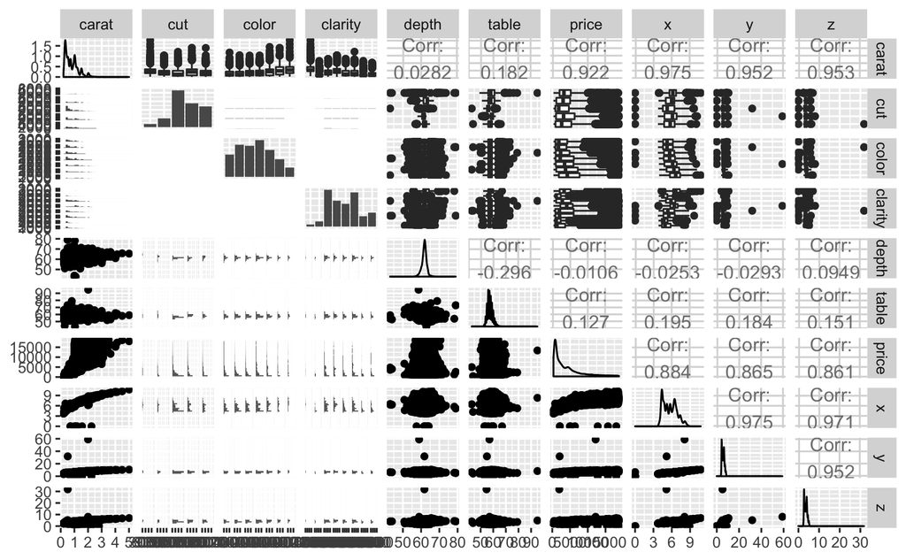

[figure not shown]

```r
ggpairs(diamonds)
```

3. So, we do find significant correlations. Let’s drop columns x, y and z from the dataset, in preparation to use only carat going forward.

```r
diamonds_trim <- diamonds %>%
  select(-x, -y, -z)
diamonds_trim
```

| carat | cut | color | clarity | depth | table | price |
| --- | --- | --- | --- | --- | --- | --- |
| 0.23 | Ideal | E | SI2 | 61.5 | 55.0 | 326 |
| 0.21 | Premium | E | SI1 | 59.8 | 61.0 | 326 |
| 0.23 | Good | E | VS1 | 56.9 | 65.0 | 327 |
| 0.29 | Premium | I | VS2 | 62.4 | 58.0 | 334 |
| 0.31 | Good | J | SI2 | 63.3 | 58.0 | 335 |
| 0.24 | Very Good | J | VVS2 | 62.8 | 57.0 | 336 |
| 0.24 | Very Good | I | VVS1 | 62.3 | 57.0 | 336 |
| 0.26 | Very Good | H | SI1 | 61.9 | 55.0 | 337 |
| 0.22 | Fair | E | VS2 | 65.1 | 61.0 | 337 |
| 0.23 | Very Good | H | VS1 | 59.4 | 61.0 | 338 |

[output cut: 990 more lines]

```r
view(diamonds_trim)
```

```r
summary(diamonds_trim)
```

```
     carat            cut               color             clarity              depth           table
 Min.   :0.2000   Length:53940       Length:53940       Length:53940       Min.   :43.00   Min.   :43.00
 1st Qu.:0.4000   Class :character   Class :character   Class :character   1st Qu.:61.00   1st Qu.:56.00
 Median :0.7000   Mode  :character   Mode  :character   Mode  :character   Median :61.80   Median :57.00
 Mean   :0.7979                                                            Mean   :61.75   Mean   :57.46
 3rd Qu.:1.0400                                                            3rd Qu.:62.50   3rd Qu.:59.00
 Max.   :5.0100                                                            Max.   :79.00   Max.   :95.00
     price
 Min.   :  326
 1st Qu.:  950
 Median : 2401
 Mean   : 3933
 3rd Qu.: 5324
 Max.   :18823
```

4. We are interested in developing a regression model for the price of a diamond in terms of the possible predictor variables in the dataset.

i.Use ggpairs() to investigate correlations between price and the predictors (this may take a while to run, don’t worry, make coffee or something).

ii.Perform further ggplot visualisations of any significant correlations you find.

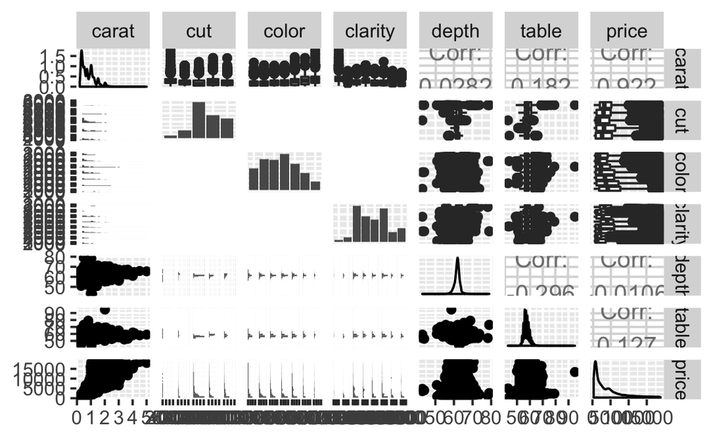

```r
ggpairs(diamonds_trim)
```

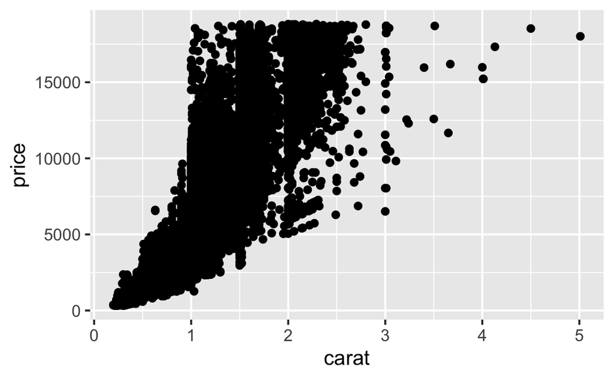

```r
diamonds_trim %>%
  ggplot(aes(x = carat, y = price)) +
  geom_point()
```

5.Shortly we may try a regression fit using one or more of the categorical predictors cut, clarity and color, so let’s investigate these predictors:

i.Investigate the factor levels of these predictors. How many dummy variables do you expect for each of them?

ii.Use the dummy_cols() function in the fastDummies package to generate dummies for these predictors and check the number of dummies in each case.

```r
library(fastDummies)
```

```r
?dummy_cols
```

```r
diamonds_trim %>%
  distinct(cut)
```

| cut |
| --- |
| Ideal |
| Premium |
| Good |
| Very Good |
| Fair |

```r
diamonds_trim %>%
  distinct(clarity)
```

| clarity |
| --- |
| SI2 |
| SI1 |
| VS1 |
| VS2 |
| VVS2 |
| VVS1 |
| I1 |
| IF |

```r
diamonds_trim %>%
  distinct(color)
```

| color |
| --- |
| E |
| I |
| J |
| H |
| F |
| G |
| D |

```r
diamonds_dummy_cut <- diamonds_trim %>%
  dummy_cols(select_columns = "cut", remove_first_dummy = TRUE,
                          remove_selected_columns = TRUE)

diamonds_dummy_cut
```

| carat | color | clarity | depth | table | price | cut_Premium | cut_Good | cut_Very Good | cut_Fair |
| --- | --- | --- | --- | --- | --- | --- | --- | --- | --- |
| 0.23 | E | SI2 | 61.5 | 55.0 | 326 | 0 | 0 | 0 | 0 |
| 0.21 | E | SI1 | 59.8 | 61.0 | 326 | 1 | 0 | 0 | 0 |
| 0.23 | E | VS1 | 56.9 | 65.0 | 327 | 0 | 1 | 0 | 0 |
| 0.29 | I | VS2 | 62.4 | 58.0 | 334 | 1 | 0 | 0 | 0 |
| 0.31 | J | SI2 | 63.3 | 58.0 | 335 | 0 | 1 | 0 | 0 |
| 0.24 | J | VVS2 | 62.8 | 57.0 | 336 | 0 | 0 | 1 | 0 |
| 0.24 | I | VVS1 | 62.3 | 57.0 | 336 | 0 | 0 | 1 | 0 |
| 0.26 | H | SI1 | 61.9 | 55.0 | 337 | 0 | 0 | 1 | 0 |
| 0.22 | E | VS2 | 65.1 | 61.0 | 337 | 0 | 0 | 0 | 1 |
| 0.23 | H | VS1 | 59.4 | 61.0 | 338 | 0 | 0 | 1 | 0 |

[output cut: 990 more lines]

```r
NA
```

```r
diamonds_dummy_clarity <- diamonds_trim %>%
  dummy_cols(select_columns = "clarity", remove_first_dummy = TRUE,
                          remove_selected_columns = TRUE)

diamonds_dummy_clarity
```

| carat | cut | color | depth | table | price | clarity_SI1 | clarity_VS1 | clarity_VS2 | clarity_VVS2 | clarity_VVS1 | clarity_I1 | clarity_IF |
| --- | --- | --- | --- | --- | --- | --- | --- | --- | --- | --- | --- | --- |
| 0.23 | Ideal | E | 61.5 | 55.0 | 326 | 0 | 0 | 0 | 0 | 0 | 0 | 0 |
| 0.21 | Premium | E | 59.8 | 61.0 | 326 | 1 | 0 | 0 | 0 | 0 | 0 | 0 |
| 0.23 | Good | E | 56.9 | 65.0 | 327 | 0 | 1 | 0 | 0 | 0 | 0 | 0 |
| 0.29 | Premium | I | 62.4 | 58.0 | 334 | 0 | 0 | 1 | 0 | 0 | 0 | 0 |
| 0.31 | Good | J | 63.3 | 58.0 | 335 | 0 | 0 | 0 | 0 | 0 | 0 | 0 |
| 0.24 | Very Good | J | 62.8 | 57.0 | 336 | 0 | 0 | 0 | 1 | 0 | 0 | 0 |
| 0.24 | Very Good | I | 62.3 | 57.0 | 336 | 0 | 0 | 0 | 0 | 1 | 0 | 0 |
| 0.26 | Very Good | H | 61.9 | 55.0 | 337 | 1 | 0 | 0 | 0 | 0 | 0 | 0 |
| 0.22 | Fair | E | 65.1 | 61.0 | 337 | 0 | 0 | 1 | 0 | 0 | 0 | 0 |
| 0.23 | Very Good | H | 59.4 | 61.0 | 338 | 0 | 1 | 0 | 0 | 0 | 0 | 0 |

[output cut: 990 more lines]

```r
diamonds_dummy_color <- diamonds_trim %>%
  dummy_cols(select_columns = "color", remove_first_dummy = TRUE,
                          remove_selected_columns = TRUE)

diamonds_dummy_color
```

| carat | cut | clarity | depth | table | price | color_I | color_J | color_H | color_F | color_G | color_D |
| --- | --- | --- | --- | --- | --- | --- | --- | --- | --- | --- | --- |
| 0.23 | Ideal | SI2 | 61.5 | 55.0 | 326 | 0 | 0 | 0 | 0 | 0 | 0 |
| 0.21 | Premium | SI1 | 59.8 | 61.0 | 326 | 0 | 0 | 0 | 0 | 0 | 0 |
| 0.23 | Good | VS1 | 56.9 | 65.0 | 327 | 0 | 0 | 0 | 0 | 0 | 0 |
| 0.29 | Premium | VS2 | 62.4 | 58.0 | 334 | 1 | 0 | 0 | 0 | 0 | 0 |
| 0.31 | Good | SI2 | 63.3 | 58.0 | 335 | 0 | 1 | 0 | 0 | 0 | 0 |
| 0.24 | Very Good | VVS2 | 62.8 | 57.0 | 336 | 0 | 1 | 0 | 0 | 0 | 0 |
| 0.24 | Very Good | VVS1 | 62.3 | 57.0 | 336 | 1 | 0 | 0 | 0 | 0 | 0 |
| 0.26 | Very Good | SI1 | 61.9 | 55.0 | 337 | 0 | 0 | 1 | 0 | 0 | 0 |
| 0.22 | Fair | VS2 | 65.1 | 61.0 | 337 | 0 | 0 | 0 | 0 | 0 | 0 |
| 0.23 | Very Good | VS1 | 59.4 | 61.0 | 338 | 0 | 0 | 1 | 0 | 0 | 0 |

[output cut: 990 more lines]

6. Going forward we’ll let R handle dummy variable creation for categorical predictors in regression fitting (remember lm() will generate the correct numbers of dummy levels automatically, absorbing one of the levels into the intercept as a reference level)
1. First, we’ll start with simple linear regression. Regress price on carat and check the regression diagnostics.
2. Run a regression with one or both of the predictor and response variables log() transformed and recheck the diagnostics. Do you see any improvement?
3. Let’s use log() transformations of both predictor and response. Next, experiment with adding a single categorical predictor into the model. Which categorical predictor is best? [Hint - investigate r2 values]
4. Interpret the fitted coefficients for the levels of your chosen categorical predictor. Which level is the reference level? Which level shows the greatest difference in price from the reference level? [Hints - remember we are regressing the log(price) here, and think about what the presence of the log(carat) predictor implies. We’re not expecting a mathematical explanation]

```r
carat_model <- lm(price ~ carat, data = diamonds_trim)

carat_model
```

```
Call:
lm(formula = price ~ carat, data = diamonds_trim)

Coefficients:
(Intercept)        carat
      -2256         7756
```

```r
summary(carat_model)
```

```
Call:
lm(formula = price ~ carat, data = diamonds_trim)

Residuals:
     Min       1Q   Median       3Q      Max
-18585.3   -804.8    -18.9    537.4  12731.7

Coefficients:
            Estimate Std. Error t value Pr(>|t|)
(Intercept) -2256.36      13.06  -172.8   <2e-16 ***
carat        7756.43      14.07   551.4   <2e-16 ***
---
Signif. codes:  0 ‘***’ 0.001 ‘**’ 0.01 ‘*’ 0.05 ‘.’ 0.1 ‘ ’ 1

Residual standard error: 1549 on 53938 degrees of freedom
Multiple R-squared:  0.8493,    Adjusted R-squared:  0.8493
F-statistic: 3.041e+05 on 1 and 53938 DF,  p-value: < 2.2e-16
```

```r
log_carat_model <- lm(log(price) ~ log(carat), data = diamonds_trim)

log_carat_model
```

```
Call:
lm(formula = log(price) ~ log(carat), data = diamonds_trim)

Coefficients:
(Intercept)   log(carat)
      8.449        1.676
```

```r
summary(log_carat_model)
```

```
Call:
lm(formula = log(price) ~ log(carat), data = diamonds_trim)

Residuals:
     Min       1Q   Median       3Q      Max
-1.50833 -0.16951 -0.00591  0.16637  1.33793

Coefficients:
            Estimate Std. Error t value Pr(>|t|)
(Intercept) 8.448661   0.001365  6190.9   <2e-16 ***
log(carat)  1.675817   0.001934   866.6   <2e-16 ***
---
Signif. codes:  0 ‘***’ 0.001 ‘**’ 0.01 ‘*’ 0.05 ‘.’ 0.1 ‘ ’ 1

Residual standard error: 0.2627 on 53938 degrees of freedom
Multiple R-squared:  0.933, Adjusted R-squared:  0.933
F-statistic: 7.51e+05 on 1 and 53938 DF,  p-value: < 2.2e-16
```

```r
cut_model <- lm(log(price) ~ log(carat) + cut, data = diamonds_trim)
cut_model
```

```
Call:
lm(formula = log(price) ~ log(carat) + cut, data = diamonds_trim)

Coefficients:
 (Intercept)    log(carat)       cutGood      cutIdeal    cutPremium  cutVery Good
      8.2001        1.6958        0.1632        0.3172        0.2382        0.2408
```

```r
summary(cut_model)
```

```
Call:
lm(formula = log(price) ~ log(carat) + cut, data = diamonds_trim)

Residuals:
     Min       1Q   Median       3Q      Max
-1.52247 -0.16484 -0.00587  0.16087  1.38115

Coefficients:
             Estimate Std. Error t value Pr(>|t|)
(Intercept)  8.200125   0.006343 1292.69   <2e-16 ***
log(carat)   1.695771   0.001910  887.68   <2e-16 ***
cutGood      0.163245   0.007324   22.29   <2e-16 ***
cutIdeal     0.317212   0.006632   47.83   <2e-16 ***
cutPremium   0.238217   0.006716   35.47   <2e-16 ***
cutVery Good 0.240753   0.006779   35.52   <2e-16 ***
---
Signif. codes:  0 ‘***’ 0.001 ‘**’ 0.01 ‘*’ 0.05 ‘.’ 0.1 ‘ ’ 1

Residual standard error: 0.2545 on 53934 degrees of freedom
Multiple R-squared:  0.9371,    Adjusted R-squared:  0.9371
F-statistic: 1.607e+05 on 5 and 53934 DF,  p-value: < 2.2e-16
```

```r
clarity_model <- lm(log(price) ~ log(carat) + clarity, data = diamonds_trim)
summary(clarity_model)
```

```
Call:
lm(formula = log(price) ~ log(carat) + clarity, data = diamonds_trim)

Residuals:
     Min       1Q   Median       3Q      Max
-0.97521 -0.12085  0.01048  0.12561  1.85854

Coefficients:
            Estimate Std. Error t value Pr(>|t|)
(Intercept) 7.768115   0.006940 1119.25   <2e-16 ***
log(carat)  1.806424   0.001514 1193.23   <2e-16 ***
clarityIF   1.114625   0.008376  133.07   <2e-16 ***
claritySI1  0.624558   0.007163   87.19   <2e-16 ***
claritySI2  0.479658   0.007217   66.46   <2e-16 ***
clarityVS1  0.820461   0.007306  112.30   <2e-16 ***
clarityVS2  0.775248   0.007197  107.72   <2e-16 ***
clarityVVS1 1.028298   0.007745  132.77   <2e-16 ***
clarityVVS2 0.979221   0.007529  130.05   <2e-16 ***
---
Signif. codes:  0 ‘***’ 0.001 ‘**’ 0.01 ‘*’ 0.05 ‘.’ 0.1 ‘ ’ 1

Residual standard error: 0.1888 on 53931 degrees of freedom
Multiple R-squared:  0.9654,    Adjusted R-squared:  0.9654
F-statistic: 1.879e+05 on 8 and 53931 DF,  p-value: < 2.2e-16
```

```r
colour_model <- lm(log(price) ~ log(carat) + color, data = diamonds_trim)
summary(colour_model)
```

```
Call:
lm(formula = log(price) ~ log(carat) + color, data = diamonds_trim)

Residuals:
     Min       1Q   Median       3Q      Max
-1.49987 -0.14888  0.00257  0.15316  1.27815

Coefficients:
             Estimate Std. Error  t value Pr(>|t|)
(Intercept)  8.572034   0.003051 2809.531  < 2e-16 ***
log(carat)   1.728631   0.001814  952.727  < 2e-16 ***
colorE      -0.025460   0.003748   -6.793 1.11e-11 ***
colorF      -0.034455   0.003773   -9.132  < 2e-16 ***
colorG      -0.055399   0.003653  -15.166  < 2e-16 ***
colorH      -0.189859   0.003917  -48.468  < 2e-16 ***
colorI      -0.286928   0.004383  -65.467  < 2e-16 ***
colorJ      -0.425038   0.005417  -78.466  < 2e-16 ***
---
Signif. codes:  0 ‘***’ 0.001 ‘**’ 0.01 ‘*’ 0.05 ‘.’ 0.1 ‘ ’ 1

Residual standard error: 0.2372 on 53932 degrees of freedom
Multiple R-squared:  0.9454,    Adjusted R-squared:  0.9454
F-statistic: 1.333e+05 on 7 and 53932 DF,  p-value: < 2.2e-16
```